# Geometric and Binomial Distributions

Applied Statistics

MTH-361A | Spring 2026 | University of Portland

# Objectives

- **Develop and understanding of the geometric distribution**
- **Develop and understanding of the binomial distribution**
- **Know how to compute geometric and binomial probabilities using R**
- **Introduce how to simulate binomial and geometric random sampling in R**

# Visualizing the Geometric Distribution (1/2)

**Geometric Probability Mass Function (PMF)**

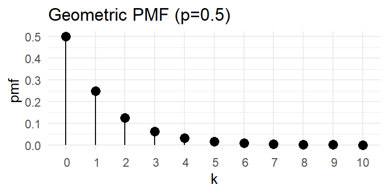

$\star$ The geometric r.v. has infinitely sized sample space. The plot of the geometric PMF only shows the first $11$ possible outcomes.

**Geometric R.V. and PMF:**

Let $p$ be the “success” probability.

- $\displaystyle X \sim \text{Geom}\left(p\right)$
- $\displaystyle P(X=k) = \left(1-p\right)^k p \quad \text{for } k = 0,1,2, \cdots$

**Relevant R Functions:**

- `dgeom` $\leftarrow$ PMF
- `rgeom` $\leftarrow$ random sampling simulation

# Visualizing the Geometric Distribution (2/2)

**Geometric Cumulative Distribution Function (CDF)**

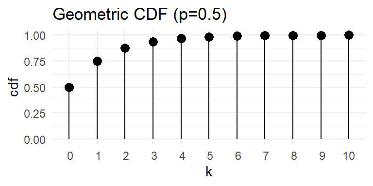

$\star$ The CDF, in general, computes the cumulative probability of a given PMF.

**Geometric PMF and CDF:**

Let $p$ be the “success” probability.

- $\displaystyle P(X=k) = \left(1-p\right)^k p \quad \text{for } k = 0,1,2, \cdots$
- $\displaystyle P(X \le k) = \sum_{i=0}^k P(X=i) \quad \text{for } k = 0,1,2, \cdots$

**Relevant R Functions:**

- `pgeom` $\leftarrow$ CDF
- `qgeom` $\leftarrow$ Inverse CDF

# Geometric Probabilities (1/3)

**Geometric Distribution**

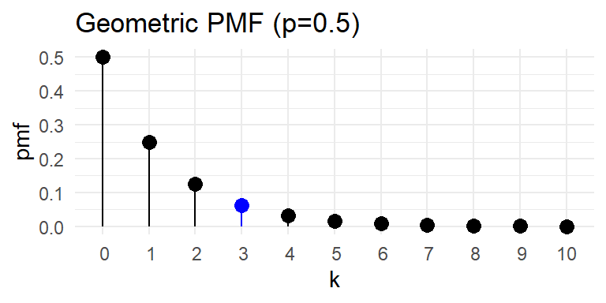

$\star$ The `dgeom()` function computes the probability $P(X = k)$, meaning it computes the probability at exactly $X=k$ number of “failures” before a “success” using the Geometric PMF.

**Example:**

*What is the probability of “success” on the 4th trial with $p = \frac{1}{2}$?*
$$\begin{aligned}
P(X=3) & = \left(1-\frac{1}{2}\right)^3 \left(\frac{1}{2}\right) \\
P(X=3) & \approx 0.063
\end{aligned}$$

**Using R:**

```r
dgeom(3,1/2)
```

```
## [1] 0.0625
```

# Geometric Probabilities (2/3)

**Geometric Distribution**

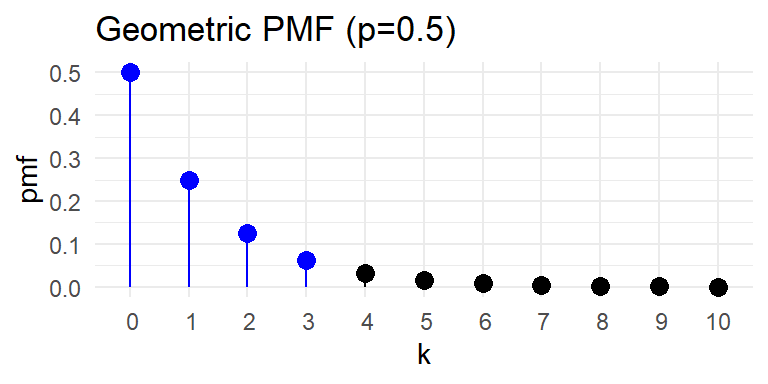

$\star$ The `pgeom()` function computes the probability $P(X \le k)$, meaning it computes the sum of all probabilities from $X=0$ to $X=k$ number of failures” before a “success” using the Geometric PMF.

**Using R:**

```r
pgeom(3,1/2)
```

```
## [1] 0.9375
```

# Geometric Probabilities (3/3)

**Geometric Distribution**

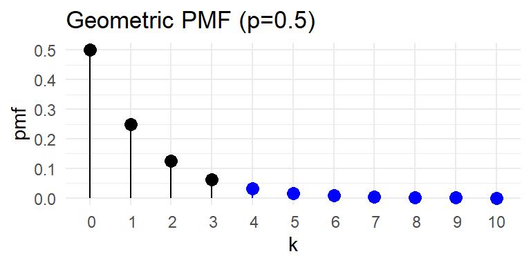

$\star$ Since $k$ is the number of “failures” before a “success” occurs, the probability of that “success” occurs at least on the 5th trial is $P(X \ge 4)$. Then, we use the complement rule.

**Example:**

*What is the probability that “success” occurs at least on the fifth trial, given $p = \frac{1}{2}$?*
$$\begin{aligned}
P(X \ge 4) & = 1 - P(X \le 3) \\
& = 1 - \sum_{i=0}^3 P(X = i) \\
& = 1 - \sum_{i=0}^3 \left(1-\frac{1}{2}\right)^{i}
\left(\frac{1}{2}\right) \\
& \approx 1 - 0.938 \\
P(X \ge 4) & \approx 0.063 \\
\end{aligned}$$

**Using R:**

```r
1-pgeom(3,1/2)
```

```
## [1] 0.0625
```

# Geometric Interval Probabilities

**Geometric Distribution**

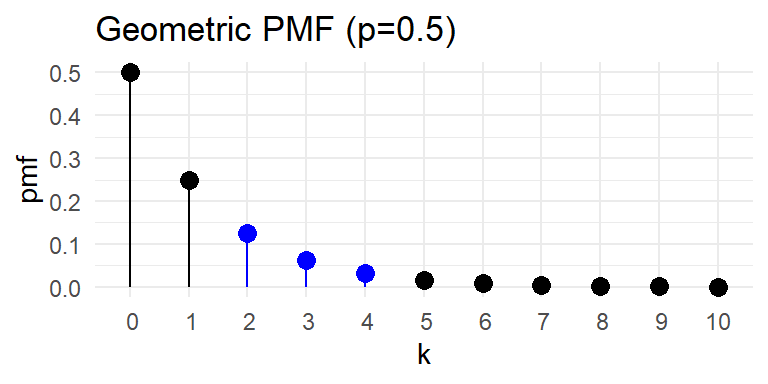

$\star$ Here, you need $P(2 \le X \le 4)$, which is equivalent to the upper bound $P(X \le 4)$ minus the lower bound $P(X \le 1)$. Note that the lower bound is reduced by one because we want to include $P(X = 2)$.

**Example:**

*What is the probability that “success” occurs between the 3rd and 5th trial, given $p = \frac{1}{2}$?*
$$\begin{aligned}
P(2 \le X \le 4) & = P(X \le 4) - P(X \le 1) \\
& = \sum_{i=0}^4 P(X = i) - \sum_{i=0}^1 P(X = i) \\
& = \sum_{i=2}^4 P(X = i) \\
& = \sum_{i=2}^4 \left(1-\frac{1}{2}\right)^{i}
\left(\frac{1}{2}\right) \\
P(2 \le X \le 4) & \approx 0.219 \\
\end{aligned}$$

**Using R:**

```r
pgeom(4,1/2)-pgeom(1,1/2)
```

```
## [1] 0.21875
```

# Geometric R.V. Expected Value

**Geometric Distribution with Expected Value:**

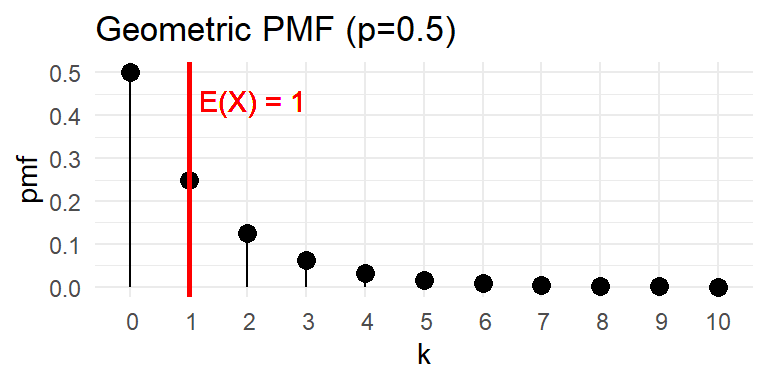

$\star$ The law of large numbers still can be used to interpret the expected value, which in this case, you would expect to have $1$ “failure” before a “success” occurs in the long run.

**Geometric R.V.:**

Let $p=\frac{1}{2}$ be the success probability.

- $\displaystyle X \sim \text{Geom}\left(\frac{1}{2}\right)$
- $\displaystyle P(X=k) = \left(1-\frac{1}{2}\right)^k \left(\frac{1}{2}\right) \quad \text{for } k = 0,1,2, \cdots$
- $\displaystyle \text{E}(X) = 1$

In general,
$$\begin{aligned}
\text{E}(X) & = \sum_{k=0}^{\infty} k P(X=k) \\
& = \sum_{k=0}^{\infty} k \left(1-p\right)^k p \\
\text{E}(X) & = \frac{1-p}{p}
\end{aligned}.$$

# Geometric R.V. Variance

Recall that the formula for the variance is
$$\text{Var}(X) = \text{E}\left(X^2 \right) -
\left( \text{E}(X) \right)^2,$$
where:

- $\displaystyle \text{E}(X) = \frac{1-p}{p} \leftarrow \text{ expected value}$
- $\displaystyle \text{E}\left(X^2\right) = \frac{(1-p)(2-p)}{p^2} \leftarrow \text{ 2nd raw moment}$

In general,
$$\begin{aligned}
\text{Var}(X) & = \text{E}\left(X^2 \right) - \left( \text{E}(X)
\right)^2 \\
& = \frac{(1-p)(2-p)}{p^2} - \left( \frac{1-p}{p} \right)^2 \\
\text{Var}(X) & = \frac{1-p}{p^2}
\end{aligned}$$

$\star$ The Geometric r.v. is at its most uncertain if $p \to 0$, meaning that if the probability of “success” is very low, then expected number of “failures” increases.

# Simulating the Geometric Distribution

**Random Sampling from the Geometric Distribution:**

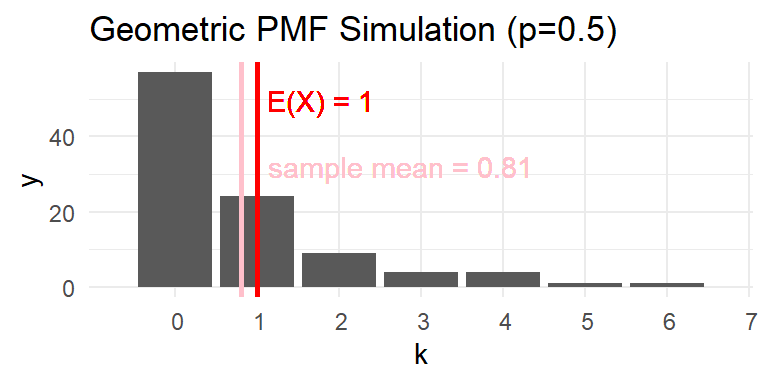

A simulation of $100$ random samples using the Geometric PMF with $p = \frac{1}{2}$.

**Sample Mean vs the Expected Value:**

The sample mean of $0.81$ is not exactly equal to the expected value of $1$ due to sampling variability.

If we increase the number of samples, the sample mean will get closer to the expectation due to the law of large numbers.

**Using R:**

```r
set.seed(42) # set seed for reproducibility
samples <- rgeom(100,1/2) # generate random samples
mean(samples) # compute sample mean
```

```
## [1] 0.81
```

# Visualizing the Binomial Distribution (1/2)

**Binomial Probability Mass Function (PMF)**

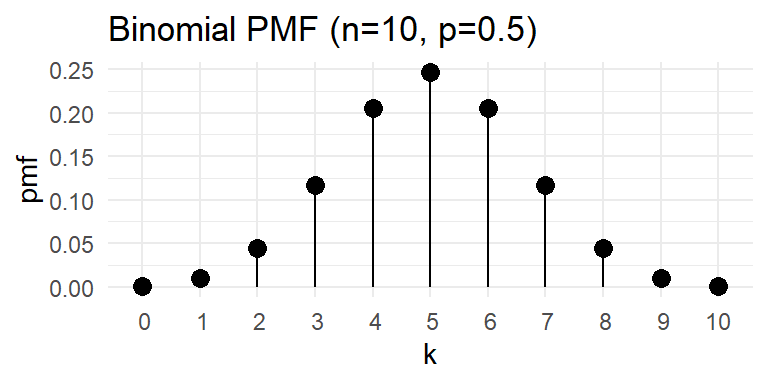

$\star$ In comparison with the Geometric PMF, the Binomial PMF has a finitely size sample space, which is $n$, the number of trials.

**Binomial R.V. and PMF**

Let $p=\frac{1}{2}$ be the “success” probability and $n=10$ the number of trials.

- $\displaystyle X \sim \text{Binom}(p)$
- $\displaystyle P(X=k) = \binom{n}{k} p^k (1-p)^{n-k} \quad \text{for } k = 0,1,2, \cdots, n$

**Relevant R Functions:**

- `dbinom` $\leftarrow$ PMF
- `rbinom` $\leftarrow$ random sampling simulation

$\star$ If you set $n=1$, the Binomial PMF reduces to the Bernoulli PMF.

# Visualizing the Binomial Distribution (2/2)

**Binomial Cumulative Distribution Function (CDF)**

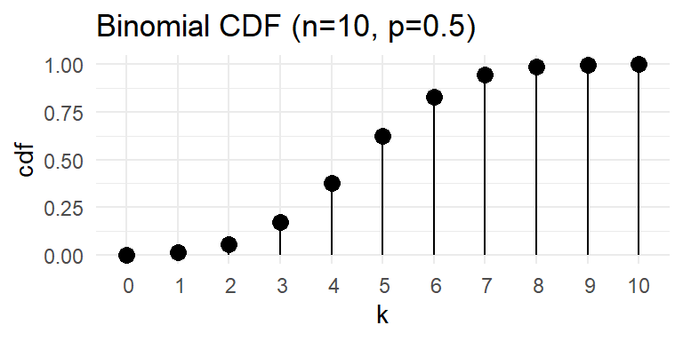

$\star$ Since the Binomial r.v. has finitely sized sample space, then $P(X \le n) = 1$.

**Binomial PMF and CDF:**

Let $p=\frac{1}{2}$ be the “success” probability and $n=10$ the number of trials.

- $\displaystyle P(X=k) = \binom{n}{k} p^k (1-p)^{n-k} \quad \text{for } k = 0,1,2, \cdots, n$
- $\displaystyle P(X \le k) = \sum_{i=0}^k P(X=i) \quad \text{for } k = 0,1,2, \cdots, n$

**Relevant R Functions:**

- `pbinom` $\leftarrow$ CDF
- `qbinom` $\leftarrow$ Inverse CDF

# Binomial Probabilities (1/3)

**Binomial Distribution**

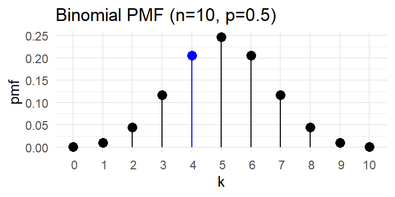

**Example:**

*What is the probability of getting 4 “success” in 10 trials with $p=\frac{1}{2}$?*
$$\begin{aligned}
P(X=4) & = \binom{10}{4} \left(\frac{1}{2}\right)^4
\left(1-\frac{1}{2}\right)^{10-4} \\
& = 210 \left(\frac{1}{2}\right)^4
\left(1-\frac{1}{2}\right)^{6} \\
P(X=4) & \approx 0.205
\end{aligned}$$

**Using R:**

```r
dbinom(4,10,1/2)
```

```
## [1] 0.2050781
```

$\star$ The `dbinom()` function computes the probability $P(X = k)$, meaning it computes the probability at exactly $X=k$ using the Binomial PMF.

# Binomial Probabilities (2/3)

**Binomial Distribution**

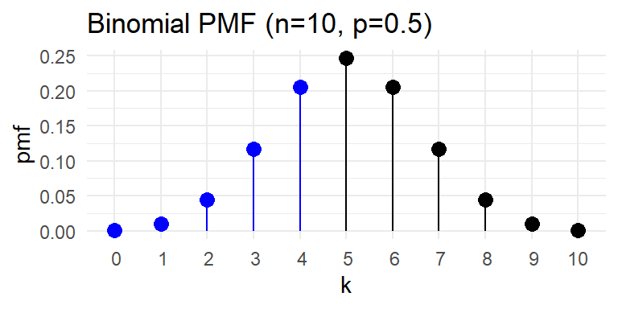

$\star$ The `pbinom()` function computes the probability $P(X \le k)$, meaning it computes the sum of all probabilities from $X=0$ to $X=k$ using the Binomial PMF.

**Example:**

*What is the probability of getting at most 4 “success” in 10 trials with $p=\frac{1}{2}$?*
$$\begin{aligned}
P(X \le 4) & = \sum_{i=0}^4 P(X = i) \\
& = \sum_{i=0}^4 \binom{10}{k} \left(\frac{1}{2}\right)^i
\left(1-\frac{1}{2}\right)^{10-i} \\
P(X \le 4) & \approx 0.377 \\
\end{aligned}$$

**Using R:**

```r
pbinom(4,10,1/2)
```

```
## [1] 0.3769531
```

# Binomial Probabilities (3/3)

**Binomial Distribution**

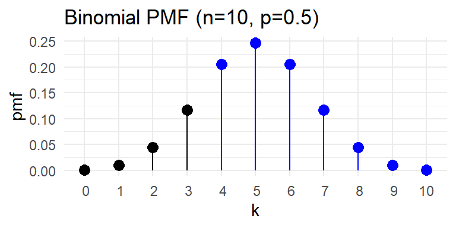

$\star$ Since we want the probability of 4 or more “success” in 10 trials, we need $P(X \ge 4)$. Then, we use the complement rule.

**Example:**

*What is the probability of getting at least 4 “success” in 10 trials with $p=\frac{1}{2}$?*
$$\begin{aligned}
P(X \ge 4) & = 1 - P(X \le 3) \\
& = 1 - \sum_{i=0}^3 P(X = i) \\
& = 1 - \sum_{i=0}^3 \binom{10}{i}
\left(\frac{1}{2}\right)^i \left(1-\frac{1}{2}\right)^{10-i} \\
& \approx 1 - 0.172 \\
P(X \ge 4) & \approx 0.828 \\
\end{aligned}$$

**Using R:**

```r
1-pbinom(3,10,1/2)
```

```
## [1] 0.828125
```

# Binomial Interval Probabilities

**Binomial Distribution**

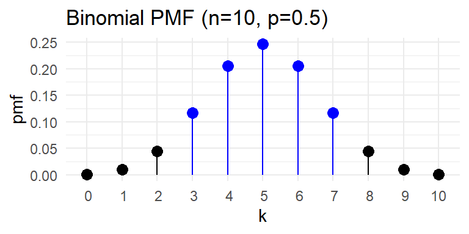

$\star$ Here, you need $P(3 \le X \le 7)$, which is equivalent to the upper bound $P(X \le 7)$ minus the lower bound $P(X \le 2)$. Note that the lower bound is reduced by one because we want to include $P(X = 3)$.

**Example:**

*What is the probability of getting between 3 to 7 “success” in 10 trials with $p=\frac{1}{2}$?*
$$\begin{aligned}
P(3 \le X \ge 7) & = P(X \le 7) - P(X \le 2) \\
& = \sum_{i=0}^7 P(X = i) - \sum_{i=0}^2 P(X = i) \\
& = \sum_{i=3}^7 P(X = i) \\
& = \sum_{i=3}^7 \binom{10}{i} \left(\frac{1}{2}\right)^i
\left(1-\frac{1}{2}\right)^{10-i} \\
P(3 \le X \ge 7) & \approx 0.891 \\
\end{aligned}$$

**Using R:**

```r
pbinom(7,10,1/2)-pbinom(2,10,1/2)
```

```
## [1] 0.890625
```

# Binomial R.V. Expected Value

**Binomial Distribution with Expected Value:**

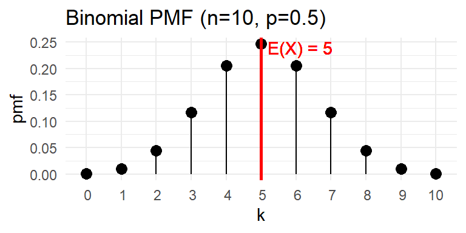

$\star$ The law of large numbers still can be used to interpret the expected value, which in this case, you would expect to $5$ “successes” out of $10$ trials in the long run.

**Binomial R.V.:**

Let $p=\frac{1}{2}$ be the success probability and $n=10$ the number of trials.

- $\displaystyle X \sim \text{Binom}\left(\frac{1}{2}\right)$
- $\displaystyle P(X=k) = \binom{10}{k} \left(\frac{1}{2}\right)^k \left(1-\frac{1}{2}\right)^{10-k} \quad \text{for } k = 0,1,2, \cdots, 10$
- $\displaystyle \text{E}(X) = 5$

In general,
$$\begin{aligned}
\text{E}(X) & = \sum_{k=0}^{n} k P(X=k) \\
& = \sum_{k=0}^{n} k \binom{n}{k} p^k \left(1-p\right)^{n-k} \\
\text{E}(X) & = np
\end{aligned}.$$

# Binomial R.V. Variance

Recall that the formula for the variance is
$$\text{Var}(X) = \text{E}\left(X^2 \right) -
\left( \text{E}(X) \right)^2,$$
where:

- $\displaystyle \text{E}(X) = np \leftarrow \text{ expected value}$
- $\displaystyle \text{E}\left(X^2\right) = (np)^2 + np(1-p) \leftarrow \text{ 2nd raw moment}$

In general,
$$\begin{aligned}
\text{Var}(X) & = \text{E}\left(X^2 \right) - \left( \text{E}(X)
\right)^2 \\
& = (np)^2 + np(1-p) - (np)^2 \\
\text{Var}(X) & = np(1-p)
\end{aligned}$$

$\star$ The variance of the Binomial r.v. is similar to the variance of the Bernoulli r.v., where the r.v. is at its most uncertain is when $p = \frac{1}{2}$.

# Simulating the Binomial Distribution

[figure not shown]

**Sample Mean vs the Expected Value**

If we increase the number of samples, the sample mean will get closer to the expectation due to the law of large numbers.

**Using R:**

```r
set.seed(42) # set seed for reproducibility
samples <- rbinom(100,10,1/2) # generate random samples
mean(samples) # compute sample mean
```

```
## [1] 5.07
```

# Summary of Discrete R.V.s and their Properties

|  | **Bernoulli** | **Geometric** | **Binomial** |
| --- | --- | --- | --- |
| *Description* | “success” or “failure” outcome in 1 independent trial | Number of “failure” independent trials before a “success” | Number of “success” in $n$ independent trials |
| *Parameters* | $p \leftarrow$ probability of “success” | $p \leftarrow$ probability of “success” | $n \leftarrow$ number of trials $p \leftarrow$ probability of “success” |
| $\displaystyle X$ | $\displaystyle \text{Bern}(p)$ | $\displaystyle \text{Geom}(p)$ | $\displaystyle \text{Binom}(n,p)$ |
| $\displaystyle \text{E}(X)$ | $\displaystyle p$ | $\displaystyle \frac{1-p}{p}$ | $\displaystyle np$ |
| $\displaystyle \text{Var}(X)$ | $\displaystyle p(1-p)$ | $\displaystyle \frac{1-p}{p^2}$ | $\displaystyle np(1-p)$ |

# Summary of Discrete R.V.s and their PMFs

|  | **Bernoulli** | **Geometric** | **Binomial** |
| --- | --- | --- | --- |
| $\displaystyle P(X = k)$ *PMF* | $\displaystyle p^k (1-p)^{1-k}$ $\text{for } k = 0,1$ | $\displaystyle (1-p)^k p$ $\text{for } k=0,1,2,\cdots$ | $\displaystyle \binom{n}{k} p^k (1-p)^{n-k}$ $\text{for } k = 0,1,2, \cdots, n$ |
| *R PMF* | `dbinom` | `dgeom` | `dbinom` |
| *R CDF* | `pbinom` | `pgeom` | `pbinom` |
| *R Inverse CDF* | `qbinom` | `qgeom` | `qbinom` |
| *R Simulations* | `rbinom` | `rgeom` | `rbinom` |

$\star$ The Binomial r.v. reduces to the Bernoulli r.v. if $n=1$.